# Tweet Storm on the Horizon

# Overview

President Trump, love him or hate him or just don’t care, is the most famous & powerful Twitter user of all time. Like it or not, President Trump’s tweets have become a source of information. The New York Times, Wall Street Journal and others news outlets and take a look at President Trump’s Tweets why shouldn’t we? This week let’s put politics aside and let the data do the talking! You can either use my dataset “TrumpQ12020Tweets.csv” or grab the latest tweets from the http://www.trumptwitterarchive.com/. Just be sure to grab enough to do some analysis - i.e. 3 months or more.

## Load Libraries

library(tidyverse) library(lubridate) library(tidytext) library(topicmodels) library(wordcloud2)

```r
options(warn = -1)
library(tidyverse)
library(lubridate)
library(tidytext)
library(topicmodels)
library(wordcloud2)
```

### load tweets

Note the data is pipe delimited( delim = “|”) so you’ll need to read them with read_delim instead of read_csv, if you read ahead you’ll also see that you might need to transform created_at as a date variable (col_types = cols(created_at = col_datetime(format = “%m-%d-%Y %H:%M:%S”)))

“TrumpQ12020Tweets.csv”

```r
tweet <- read_delim("TrumpQ12020Tweets.csv") %>%
  mutate(created_at = as.Date(created_at, format = "%m-%d-%Y %H:%M:%S"))

tweet
```

| source | text | created_at | retweet_count | favorite_count | is_retweet | id_str |
| --- | --- | --- | --- | --- | --- | --- |
| Twitter for iPhone | Will be interviewed on @foxandfriends at 7:55 A.M. USA STRONG! | 2020-03-30 | 15419 | 94155 | false | 1244493463355342848 |
| Twitter for iPhone | RT @SteveFDA: We issued a new authorization this evening to @Battelle for their decontamination system. @US_FDA staff have been working non… | 2020-03-30 | 6913 | 0 | false | 1244478744384987136 |
| Twitter for iPhone | RT @GovMikeDeWine: Thank you @realDonaldTrump and @SteveFDA! @US_FDA has now given Columbus-based @Battelle full approval of the use of ne… | 2020-03-30 | 9050 | 0 | false | 1244478710956339200 |
| Twitter for iPhone | https://t.co/YzhyVR1N6d | 2020-03-29 | 13735 | 65496 | false | 1244409814064775169 |
| Twitter for iPhone | https://t.co/MtEehGY9cp | 2020-03-29 | 14134 | 60385 | false | 1244409785681883137 |
| Twitter for iPhone | RT @WhiteHouse: LIVE: Press Briefing with Coronavirus Task Force https://t.co/io9HpU9q2o | 2020-03-29 | 10583 | 0 | false | 1244379945641656322 |
| Twitter for iPhone | Will be starting The White House news conference at 5:30 P.M. Eastern. | 2020-03-29 | 13123 | 85698 | false | 1244368213133144065 |
| Twitter for iPhone | So proud of the @USACEHQ, @FEMA, and the Federal Government for the 2,900 bed hospital they built in 4 days (way ahead of schedule) in the Javits Center for NY. We are now moving the teams to join oth… | 2020-03-29 | 16015 | 70179 | false | 1244355295033331718 |
| Twitter for iPhone | Thank you very much to Ken Langone for being a great American and for your wonderful comments on @TeamCavuto. | 2020-03-29 | 9513 | 54266 | false | 1244354540486512640 |
| Twitter for iPhone | I am a great friend and admirer of the Queen &amp; the United Kingdom. It was reported that Harry and Meghan, who left the Kingdom, would reside permanently in Canada. Now they have left Canada for th… | 2020-03-29 | 99226 | 537499 | false | 1244338645198352386 |

[output cut: 2773 more lines]

## Term Frequency & Wordcloud

create tweet_freq table

1. create a month_variable
2. parse terms into words, remove the following
- stop words
- c(“t.co”, “https”, “false”, “twitter”, “iphone”, “amp”, “rt”, “android”)
3. summarize by month and word
4. take top 100 words by month

create the following word clouds: 1. word cloud for month 1 2. word cloud for month 2 3. word cloud for month 3

answer: what terms jump out at you?

```r
tweet_freq <-
  tweet %>%
  mutate(month = month(created_at, label=TRUE, abbr=FALSE)) %>%
  filter(!is.na(month)) %>%
  unnest_tokens(word, text) %>%
  anti_join(stop_words, by = c("word" = "word")) %>%
  filter(!word %in% c("t.co", "https", "false", "twitter", "iphone", "amp", "rt", "android")) %>%
  filter(!str_detect(word, "^\\d")) %>%
  group_by(month, word) %>%
  summarize(n = n()) %>%
  ungroup() %>%
  group_by(month) %>%
  slice_max(order_by = n, n = 100)

wordcloud <- function(m){
  tweet_freq %>%
  ungroup() %>%
  filter(month == m) %>%
  select(word, n) %>%
  wordcloud2(size = 0.5)
}

for (c in c("January", "February", "March")){
  print(wordcloud(c))
}

# answer: what terms jump out at you?
# Month 1: democrats, realdonaldtrump, impeachment, ……
# Month 2: realdonaldtrump, president, trump, ……
# Month 3: realdonaldtrump, coronavirus, people, ……
```

[output not shown]

## Bigram Analysis

create table bigram_freq by 1. create a bigram  
2. use separate to split bigram into word1 and word2 then filter the following - stop words against both word1 and word2 - c(“t.co”, “https”, “false”, “twitter”, “iphone”, “amp”, “rt”, “android”) - filter digits 3. create a bigram variable by combining word1 and word2 together 4. count the bigram up.

create the following

1. make a chart of the top 10 terms that come after the word “fake”, like: “fake news”
2. make a chart of the top 10 terms that come before the word “media”, like: “mainstream media”
3. make a chart of the top 5 terms that contain the word “joe”, like “joe biden” or “sleepy joe”

answer: what jumps out at you?

```r
bigram_freq <-
  tweet %>%
  unnest_tokens(bigram, text, token = "ngrams", n = 2, n_min = 2) %>%
  separate(bigram, c("word1", "word2"), sep = " ") %>%
  filter(!word1 %in% stop_words$word) %>%
  filter(!word2 %in% stop_words$word) %>%
  filter(!word1 %in% c("t.co", "https", "false", "twitter", "iphone", "amp", "rt", "android")) %>%
  filter(!word2 %in% c("t.co", "https", "false", "twitter", "iphone", "amp", "rt", "android")) %>%
  filter(!str_detect(word1, "^\\d")) %>%
  filter(!str_detect(word2, "^\\d")) %>%
  unite(bigram, word1, word2, sep = " ") %>%
  count(bigram, sort = TRUE)

bigram_freq
```

| bigram | n |
| --- | --- |
| president realdonaldtrump | 89 |
| fake news | 66 |
| mini mike | 58 |
| president trump | 53 |
| impeachment hoax | 47 |
| american people | 44 |
| white house | 43 |
| republican party | 35 |
| adam schiff | 34 |
| joe biden | 28 |

[output cut: 8068 more lines]

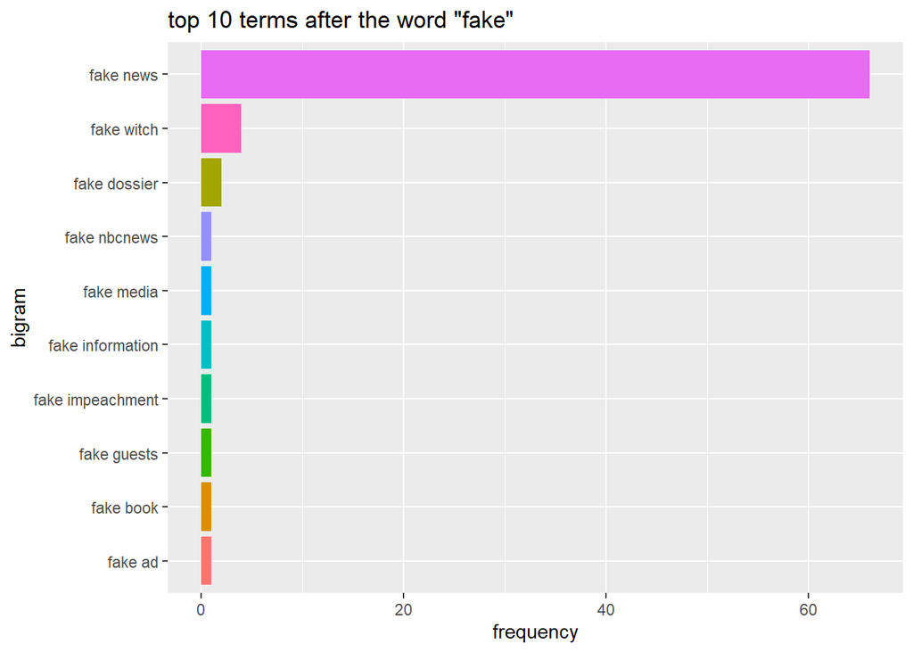

```r
bigram_freq %>%
  separate(bigram, c("word1", "word2"), sep = " ") %>%
  filter(word1 == "fake") %>%
  unite(bigram, word1, word2, sep = " ") %>%
  slice_max(order_by = n, n = 10) %>%
  head(10) %>%
  ggplot() +
  geom_col(mapping = aes(x=n, y=reorder(bigram,n), fill=factor(bigram))) +
  labs(title = 'top 10 terms after the word "fake"', x = 'frequency', y = 'bigram') +
  theme(legend.position = "none")
```

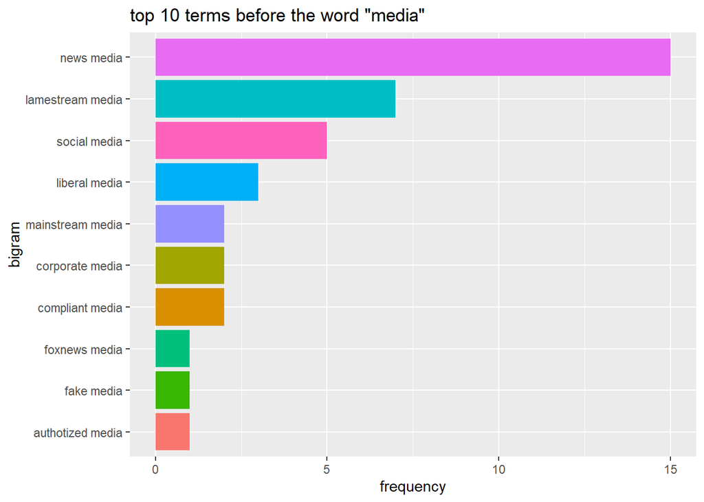

```r
bigram_freq %>%
  separate(bigram, c("word1", "word2"), sep = " ") %>%
  filter(word2 == "media") %>%
  unite(bigram, word1, word2, sep = " ") %>%
  slice_max(order_by = n, n = 10) %>%
  head(10) %>%
  ggplot() +
  geom_col(mapping = aes(x=n, y=reorder(bigram,n), fill=factor(bigram))) +
  labs(title = 'top 10 terms before the word "media"', x = 'frequency', y = 'bigram') +
  theme(legend.position = "none")
```

[figure not shown]

```r
bigram_freq %>%
  separate(bigram, c("word1", "word2"), sep = " ") %>%
  filter(word1 == "joe" | word2 == "joe") %>%
  unite(bigram, word1, word2, sep = " ") %>%
  slice_max(order_by = n, n = 5) %>%
  head(5) %>%
  ggplot() +
  geom_col(mapping = aes(x=n, y=reorder(bigram,n), fill=factor(bigram))) +
  labs(title = 'top 10 terms contain the word  "joe"', x = 'frequency', y = 'bigram') +
  theme(legend.position = "none")
```

```r
# answer: what jumps out at you?
# As for the terms after the word "fake", Trump says "fake news" the most. As for the terms before the word "media", Trump mentions "news media" the most. As for the terms that contain 'joe', Trump speaks 'joe biden' the most.
```